# group_assignment_final

```r
#overall cumsum
df_pnl$pnl_cumsum <- cumsum(df_pnl$DoD_PnL)
#option cumsum
df_pnl$opt_cumsum <- cumsum(df_pnl$Option_DoD_PnL)
#stock sumcum
df_pnl$stock_cumsum <- cumsum(df_pnl$Hedging_DoD_Pnl)
```

Overall PnL split into options and stocks, the PnL for our one-trade analysis, segmented by cumulative PnL, Option PnL and Stock PnL.

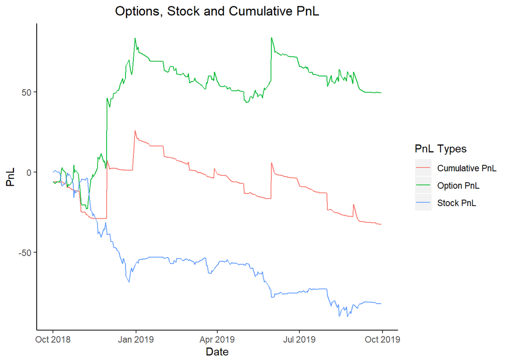

```r
# plotting the pnl

# melt the df_pnl
df_filtered <- df_pnl %>% select(date,pnl_cumsum, opt_cumsum, stock_cumsum)
colnames(df_filtered)[colnames(df_filtered)=="pnl_cumsum"] <- "Cumulative PnL"
colnames(df_filtered)[colnames(df_filtered)=="opt_cumsum"] <- "Option PnL"
colnames(df_filtered)[colnames(df_filtered)=="stock_cumsum"] <- "Stock PnL"

df_melt <- reshape2::melt(df_filtered, id.var='date')
colnames(df_melt)[colnames(df_melt)=="variable"] <- "PnL Types"
ggplot(df_melt, aes(x=date, y=value, col=`PnL Types`)) +
  geom_line() + xlab("Date") + ylab("PnL") + ggtitle("Options, Stock and Cumulative PnL")+ theme(plot.title = element_text(hjust = 0.5)) +
   theme(panel.grid.major = element_blank(), panel.grid.minor = element_blank(), panel.background = element_blank(), axis.line = element_line(colour = "black"))
```

Analysis: Option and stock daily PnL against the time to expiry. This shows us the daily fluctuation in PnL.

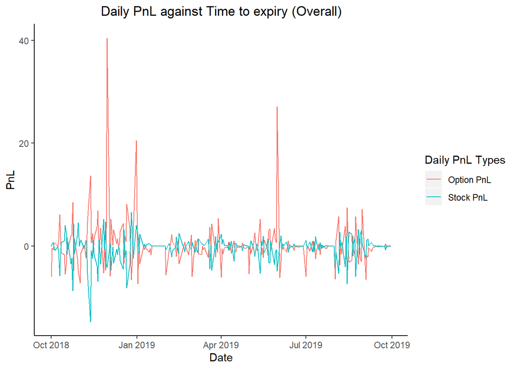

```r
# Track PnL against time to maturity.

df_filtered <- df_pnl %>% select(date,Option_DoD_PnL, Hedging_DoD_Pnl)
colnames(df_filtered)[colnames(df_filtered)=="Option_DoD_PnL"] <- "Option PnL"
colnames(df_filtered)[colnames(df_filtered)=="Hedging_DoD_Pnl"] <- "Stock PnL"

df_melt <- reshape2::melt(df_filtered, id.var='date')
colnames(df_melt)[colnames(df_melt)=="variable"] <- "Daily PnL Types"

ggplot(df_melt, aes(x=date, y=value, col=`Daily PnL Types`)) +
  geom_line() + xlab("Date") + ylab("PnL") + ggtitle("Daily PnL against Time to expiry (Overall)")+ theme(plot.title = element_text(hjust = 0.5)) +
   theme(panel.grid.major = element_blank(), panel.grid.minor = element_blank(), panel.background = element_blank(), axis.line = element_line(colour = "black"))
```

Analysis: Option and stock daily PnL against the time to expiry. This plot splits the daily PnL flunction into monthly basis. This means different colored lines represents the fluctuation in PnL in that particular month.

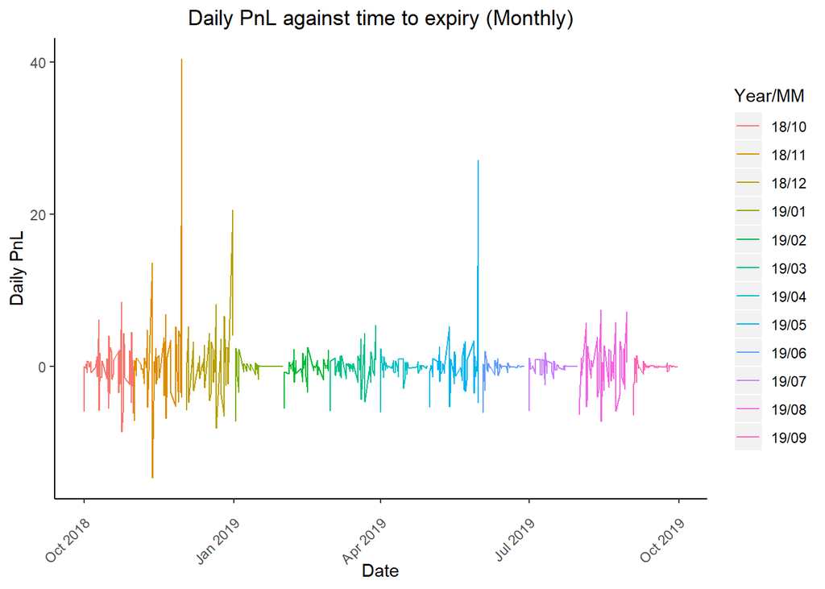

```r
# Track PnL against time to maturity.

df_filtered <- df_pnl %>% select(date,Option_DoD_PnL, Hedging_DoD_Pnl)
colnames(df_filtered)[colnames(df_filtered)=="Option_DoD_PnL"] <- "Option PnL"
colnames(df_filtered)[colnames(df_filtered)=="Hedging_DoD_Pnl"] <- "Stock PnL"


df_melt <- reshape2::melt(df_filtered, id.var='date')
colnames(df_melt)[colnames(df_melt)=="variable"] <- "PnL Types"
df_melt$M_Y<-format(df_melt$date,"%y/%m")
colnames(df_melt)[colnames(df_melt)=="M_Y"] <- "Year/MM"

ggplot(df_melt, aes(x=date, y=value, col=`Year/MM`)) +
  geom_line() + xlab("Date") + ylab("Daily PnL") + ggtitle("Daily PnL against time to expiry (Monthly)")+ theme(plot.title = element_text(hjust = 0.5))+
  theme(axis.text.x=element_text(angle=45, vjust=.8, hjust=1))+
  theme(panel.grid.major = element_blank(), panel.grid.minor = element_blank(), panel.background = element_blank(), axis.line = element_line(colour = "black"))
```

Backtesting for 1year, closing options and stocks monthly, Delta Hedge with 100 put options with Delta 0.25.

```r
df_hist_vol <- read_csv("VXGSCLS.csv",
                        col_types = cols(
                          DATE = col_date(format = "%Y-%m-%d")))

# renaming the data column to IV30
colnames(df_hist_vol)[colnames(df_hist_vol) == "VXGSCLS"] <- "IV30"
hist_vol <- df_hist_vol %>% dplyr::filter(IV30!=".")
hist_vol$IV30 <- as.numeric(hist_vol$IV30)
hist_vol <- hist_vol%>%mutate(IV30=IV30/100)

# read goldman stock data.
GS <- read_csv("GS.csv",
               col_types = cols(
                 Date = col_date(format = "%Y-%m-%d")))

get_data<-function(df1, df2){
  # df1 = hist_vol
  # df2 = GS
  # purpose of this function is to merge 2 df together and prepare for analysis of 1 trade.

  # create xts object that is easier to work on time series
  hist_vol_xts <- xts(x=hist_vol$IV30, order.by=hist_vol$DATE)
  price_xts <- xts(x=GS$Close, order.by=GS$Date)

  # price_vol_xts contains the date and the price and implied volatility.
  price_vol_xts <- merge(hist_vol_xts,price_xts,join='inner')
  # renaming the columns.
  colnames(price_vol_xts)<- c("IV30", "Close")
  return(price_vol_xts)
}

delta25<- function(S1,Time1,r1,b1,sigma1){
  X1= S1-1
  for(i in 1:100)
  {
    k1= GBSGreeks("delta", TypeFlag='p',
                                 S=S1,
                                 X=X1,
                                 Time=Time1,
                                 r=r1,
                                 b= b1,
                                 sigma=sigma1)
    if(k1 >-0.25)
      return(X1)
    X1=X1-1
    }
}
# merge the 2 dataframe.
merged <- get_data(hist_vol, GS)

# Creating the variables.
dates <- index(merged)
start_date <- min(dates)
start_price <- merged[start_date, "Close"]
start_volatility <- merged[start_date, "IV30"]

# Creating new df
df <- tibble(date = dates)
df$Close <- coredata(merged[, "Close"])
df$IV <- coredata(merged[, "IV30"])
# ATM so exercise = strike price.
X <- start_price
riskfree <- 0.8 / 100
# Vary S and Time everyday
S <- df$Close
# extract the month from the date
df$M_Y<-format(df$date,"%m-%y")

# filter such that the date ends at 09/30/2019 (exactly 12 months.)
df <- df %>% subset(date<= "2019-09-30")

# Creating the variables.
dates <- index(merged)
start_date <- min(dates)
#end_date <- max(dates)
df$day1 <- format(df$date,"%d")

#start_price <- merged[start_date, "Close"]
start_price <- delta25(df$Close[1],30,riskfree,0.0,df$IV[1])

start_volatility <- merged[start_date, "IV30"]
df$premium=0
curr_mon=df$M_Y[1]
df$premium[1]= GBSOption(TypeFlag = "p",
                             S = as.numeric(df$Close[1]),
                             X = as.numeric(start_price),
                             Time = (31-as.numeric(df$day1[1]))/365,
                             r = riskfree,
                             b = 0.0,
                             sigma = as.numeric(df$IV[1]))@price
df$Option_DoD_PnL=0
df$delta_hedge = 0
df$Hedging_DoD_Pnl = 0

#Quantity
quantity<- 100

flag=0
df$Option_DoD_PnL[1]= -1*quantity*df$premium[1]

for(i in 2:nrow(df))
{
  if(df$M_Y[i]!=curr_mon)
  {
    #start_price=df$Close[i]
    start_price <- delta25(df$Close[i],30,riskfree,0.0,df$IV[i])
    curr_mon=df$M_Y[i]
    flag=1
    #Settling on the last day of month
    df$Option_DoD_PnL[i-1]=df$Option_DoD_PnL[i-1] + quantity*df$premium[i-1]
  }
  df$premium[i] = GBSOption(TypeFlag = "p",
                             S = as.numeric(df$Close[i]),
                             X = as.numeric(start_price),
                             Time = (31-as.numeric(df$day1[i]))/365,
                             r = riskfree,
                             b = 0.0,
                             sigma = as.numeric(df$IV[i]))@price


  df$delta_hedge[i] = GBSGreeks("delta", TypeFlag='p',
                                 S=as.numeric(df$Close[i]),
                                 X=start_price,
                                 Time=(31-as.numeric(df$day1[i]))/365,
                                 r=riskfree,
                                 b= 0.0,
                                 sigma=as.numeric(df$IV[i]))
  if(flag==1){
    df$Option_DoD_PnL[i]= -1*quantity*df$premium[i]
    df$Hedging_DoD_Pnl[i-1]=0
    if(i-2>1)
      df$Hedging_DoD_Pnl[i]=-1*df$delta_hedge[i]*quantity*(df$Close[i] - df$Close[i-2])
  }
  else{
    df$Option_DoD_PnL[i]=(df$premium[i]-df$premium[i-1])*quantity
    df$Hedging_DoD_Pnl[i] = -1*df$delta_hedge[i]*quantity*(df$Close[i] - df$Close[i-1])
  }
  flag=0
}

df_pnl <- df %>% mutate(DoD_PnL = Option_DoD_PnL + Hedging_DoD_Pnl)
```

Calculating max drawdown and sharpe ratio for one-year of back-testing results.

```r
# calculating max drawdown
DOD_pnl <- df_pnl %>% {
  xs <- .$DoD_PnL
  max(na.omit(cummax(xs) - cummin(xs)))
}

# calculating sharpe ratio
sharpe <- df_pnl %>% {
  xs <- na.omit(.$DoD_PnL)
  (mean(xs) - riskfree)/sd(xs)
}

print(paste0("Max drawdown of day-to-day pnl: $", round(DOD_pnl,2)))
```

```
## [1] "Max drawdown of day-to-day pnl: $4985.78"
```

```r
print(paste0("Sharpe ratio: ", round(sharpe,2)))
```

```
## [1] "Sharpe ratio: -0.03"
```

Overall PnL split into options and stocks against time to expiry. The PnL is segmented to the option PnL and stock PnL.

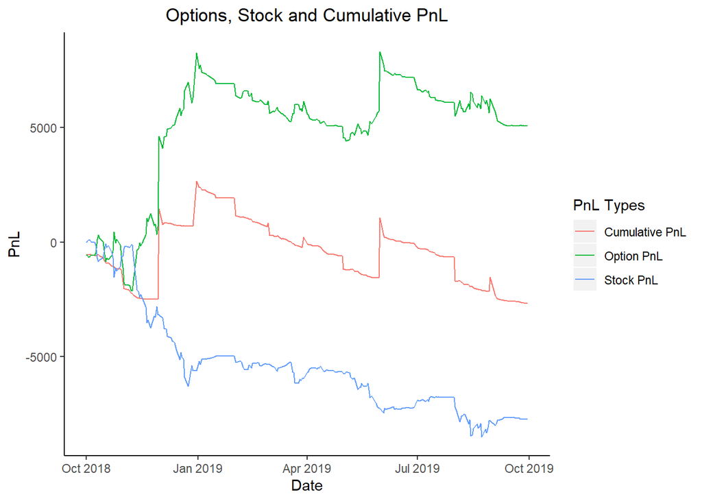

Analysis: Option and stock daily PnL against the time to expiry. This shows us the daily fluctuation in PnL.

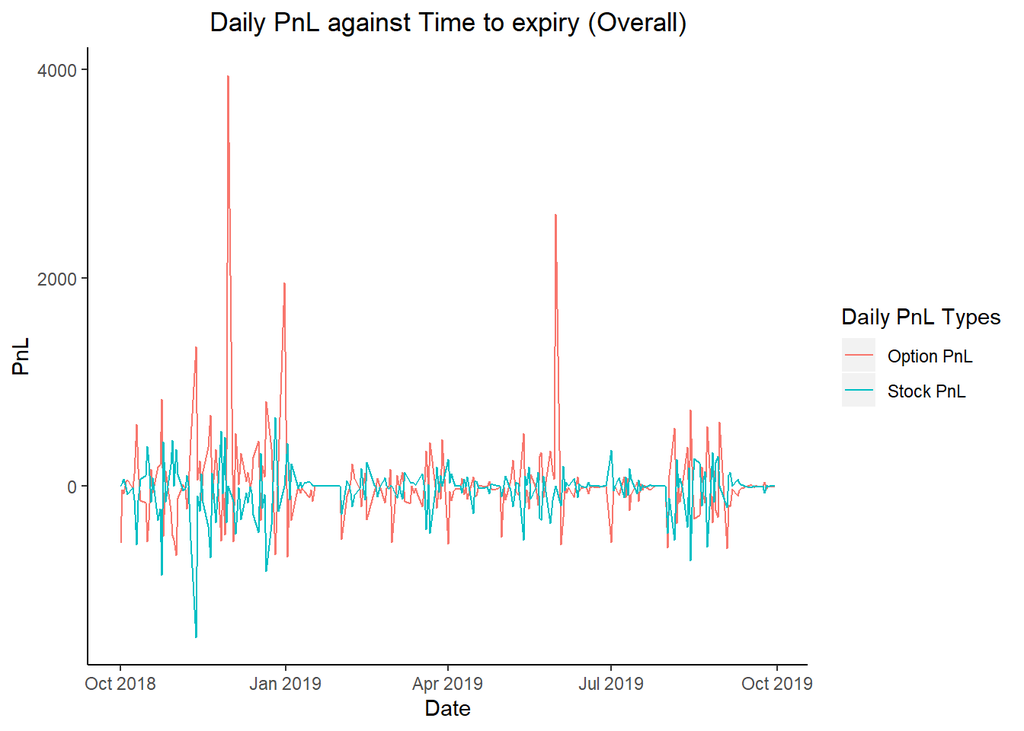

```r
# Track PnL against time to maturity.

df_filtered <- df_pnl %>% select(date,Option_DoD_PnL, Hedging_DoD_Pnl)
colnames(df_filtered)[colnames(df_filtered)=="Option_DoD_PnL"] <- "Option PnL"
colnames(df_filtered)[colnames(df_filtered)=="Hedging_DoD_Pnl"] <- "Stock PnL"

df_melt <- reshape2::melt(df_filtered, id.var='date')
colnames(df_melt)[colnames(df_melt)=="variable"] <- "Daily PnL Types"

ggplot(df_melt, aes(x=date, y=value, col=`Daily PnL Types`)) +
  geom_line() + xlab("Date") + ylab("PnL") + ggtitle("Daily PnL against Time to expiry (Overall)")+ theme(plot.title = element_text(hjust = 0.5)) +
   theme(panel.grid.major = element_blank(), panel.grid.minor = element_blank(), panel.background = element_blank(), axis.line = element_line(colour = "black"))
```

Analysis: Option and stock daily PnL against the time to expiry. This plot splits the daily PnL function into monthly basis. This means different colored lines represents the fluctuation in PnL in that particular month.

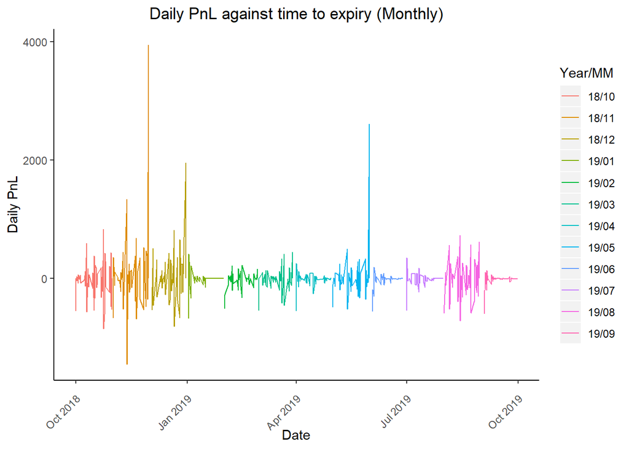

```r
# Track PnL against time to maturity.

df_filtered <- df_pnl %>% select(date,Option_DoD_PnL, Hedging_DoD_Pnl)
colnames(df_filtered)[colnames(df_filtered)=="Option_DoD_PnL"] <- "Option PnL"
colnames(df_filtered)[colnames(df_filtered)=="Hedging_DoD_Pnl"] <- "Stock PnL"


df_melt <- reshape2::melt(df_filtered, id.var='date')
colnames(df_melt)[colnames(df_melt)=="variable"] <- "PnL Types"
df_melt$M_Y<-format(df_melt$date,"%y/%m")
colnames(df_melt)[colnames(df_melt)=="M_Y"] <- "Year/MM"

ggplot(df_melt, aes(x=date, y=value, col=`Year/MM`)) +
  geom_line() + xlab("Date") + ylab("Daily PnL") + ggtitle("Daily PnL against time to expiry (Monthly)")+ theme(plot.title = element_text(hjust = 0.5))+
  theme(axis.text.x=element_text(angle=45, vjust=.8, hjust=1))+
  theme(panel.grid.major = element_blank(), panel.grid.minor = element_blank(), panel.background = element_blank(), axis.line = element_line(colour = "black"))
```

### For the 1 year of back testing results with full trade, we also included the analysis of the distribution of the max drawdown, Final PnL and sharpe ratio in each month in bar charts. We have plotted the Monthly PnL against time-to-maturity In addition, We also include the distribution in final PnL segmented by each 30 days of trade.

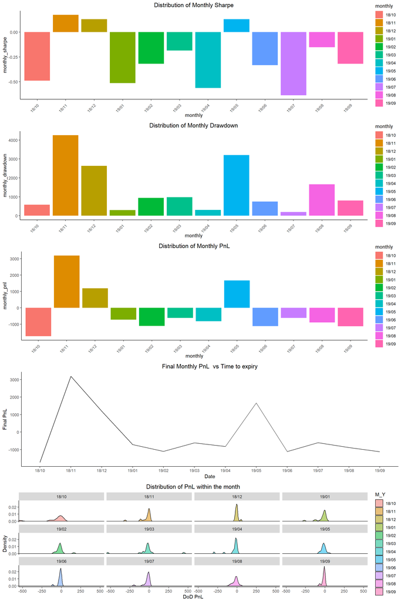

```r
# Track PnL against time to maturity.

df_filtered <- df_pnl %>% select(date, Option_DoD_PnL, Hedging_DoD_Pnl, DoD_PnL)
colnames(df_filtered)[colnames(df_filtered)=="Option_DoD_PnL"] <- "Option PnL"
colnames(df_filtered)[colnames(df_filtered)=="Hedging_DoD_Pnl"] <- "Stock PnL"
colnames(df_filtered)[colnames(df_filtered)=="DoD_PnL"] <- "DoD PnL"

df_melt <- reshape2::melt(df_filtered, id.var='date')
colnames(df_melt)[colnames(df_melt)=="variable"] <- "PnL Types"
df_melt$M_Y<-format(df_melt$date,"%y/%m")
colnames(df_melt)[colnames(df_melt)=="M_Y"] <- "Year/MM"

#Calculate the maximum drawdown in each month
df_DoD_pnL <- df_filtered %>% select(date, `DoD PnL`)
df_DoD_pnL$M_Y <-format(df_DoD_pnL$date,"%y/%m")
# colnames(df_DoD_pnL)[colnames(df_DoD_pnL)=="M_Y"] <- "Year/MM"
label_month <- unique(df_DoD_pnL$M_Y)
# storage for sharpe and max drawdown
sharpe_bank <- c()
drawdown_bank <- c()
final_pnl_bank <- c()
riskfree = 0.8/100
pos = 1
for (i in unique(df_DoD_pnL$M_Y)){
  df_selected <- df_DoD_pnL %>% dplyr::filter(M_Y == i)
  #
  max_drawdown_monthly <- df_selected %>% {
  xs <- na.omit(.$`DoD PnL`)
  max(na.omit(cummax(xs) - cummin(xs)))
  }

  sharpe_monthly <- df_selected %>% {
  xs <- na.omit(.$`DoD PnL`)
  (mean(xs) - riskfree)/sd(xs)
  }

  pnl_last_D <- df_selected %>% {
  xs <- na.omit(.$`DoD PnL`)
  na.omit(cumsum(xs))[length(xs)]
  }

  # print(paste0("pnl on last day: ", pnl_last_D))
  # print(paste0("Sharpe for each month: ", sharpe_monthly))
  # print(paste0("Max drawdown for each month: ", max_drawdown_monthly))

  drawdown_bank[i]<- as.numeric(max_drawdown_monthly)
  sharpe_bank[i]<- as.numeric(sharpe_monthly)
  final_pnl_bank[i]<- as.numeric(pnl_last_D)

  pos<- pos+1
}

df_plot = tibble(monthly=unique(df_DoD_pnL$M_Y), monthly_drawdown=drawdown_bank, monthly_sharpe=sharpe_bank, monthly_pnl = final_pnl_bank)
# plotting the histogram for monthly sharpe and monthly draw down
p1 <- ggplot(df_plot, aes(y=monthly_sharpe, x=monthly, fill=monthly)) + geom_bar(position="dodge", stat="identity") + theme(axis.text.x=element_text(angle=45, vjust=.8, hjust=1))+
  theme(plot.title = element_text(hjust = 0.5))+
  theme(panel.grid.major = element_blank(), panel.grid.minor = element_blank(), panel.background = element_blank(), axis.line = element_line(colour = "black")) + ggtitle("Distribution of Monthly Sharpe")

p2 <- ggplot(df_plot, aes(y=monthly_drawdown, x=monthly, fill=monthly)) + geom_bar(position="dodge", stat="identity") + theme(axis.text.x=element_text(angle=45, vjust=.8, hjust=1))+
  theme(plot.title = element_text(hjust = 0.5))+
  theme(panel.grid.major = element_blank(), panel.grid.minor = element_blank(), panel.background = element_blank(), axis.line = element_line(colour = "black")) + ggtitle("Distribution of Monthly Drawdown")

p3 <- ggplot(df_plot, aes(y=monthly_pnl, x=monthly, fill=monthly)) + geom_bar(position="dodge", stat="identity") + theme(axis.text.x=element_text(angle=45, vjust=.8, hjust=1))+
  theme(plot.title = element_text(hjust = 0.5))+
  theme(panel.grid.major = element_blank(), panel.grid.minor = element_blank(), panel.background = element_blank(), axis.line = element_line(colour = "black")) + ggtitle("Distribution of Monthly PnL")

p4 <- ggplot(df_plot, aes(x=monthly, y=monthly_pnl, group = 1)) +
  geom_line() + xlab("Date") + ylab("Final PnL") + ggtitle("Final Monthly PnL  vs Time to expiry")+ theme(plot.title = element_text(hjust = 0.5)) +
   theme(panel.grid.major = element_blank(), panel.grid.minor = element_blank(), panel.background = element_blank(), axis.line = element_line(colour = "black"))

p5 <- ggplot(df_DoD_pnL)+
  geom_density(aes(`DoD PnL`, fill=M_Y), alpha=0.5) +
  facet_wrap(~M_Y) +
  coord_cartesian(xlim=c(-500, 500)) +
  xlab("DoD PnL") +
  ylab("Density") +
  ggtitle("Distribution of PnL within the month") +
  theme(plot.title = element_text(hjust = 0.5)) +
  theme(panel.grid.major = element_blank(), panel.grid.minor = element_blank(),
  panel.background = element_blank(), axis.line = element_line(colour = "black"))

grid.arrange(p1, p2, p3, p4, p5, nrow = 5)
```

```r
# Create
# ggplot(df_melt, aes(x=date, y=value, col=`Year/MM`)) +
#   geom_line() + xlab("Date") + ylab("Daily PnL") + ggtitle("Daily PnL against time to expiry (Monthly)")+ theme(plot.title = element_text(hjust = 0.5))+
#   theme(axis.text.x=element_text(angle=45, vjust=.8, hjust=1))+
#   theme(panel.grid.major = element_blank(), panel.grid.minor = element_blank(), panel.background = element_blank(), axis.line = element_line(colour = "black"))
```